# The Office Report

Gerardo Antonio Lopez Ruiz, Jose Lopez Torres, Omar Pardo Gomez,

December 10th, 2018

## Introduction.

The Office is a television sitcom that aired on NBC from 2005 to 2013. It shows us the everyday lives of office employees from a paper company called Dunder Mifflin Paper Company in Scranton, Pennsylvania. While this does not seem like something interesting to watch, the show was able to captivate an average of 8 million US viewers for 9 years. As many people, we have enjoyed watching this show, and because of it, we have decided to use our data visualization techniques to solve some complex questions about the series. Our motivation comes from the desire to increase our knowledge of the sitcom in a quantitative manner, and hence, we created a framework with three guiding questions:

- Can we get a better understanding on each character’s specific profile, like who says the most jokes, or who holds the most airtime?
- Can this dataset help us understand something about the interaction among the characters, like who mentions whom the most times, or how many scenes are shared by groups like Michael and Dwight, or Jim and Pam?
- Would the scripts help us understand any impact the show might have had on society? For instance, do males play a bigger role on the show? How did viewership change as time passed and how did it react to changes in the original cast?

We expect to be able to solve them mostly based on the data we obtained from [(1)](https://docs.google.com/spreadsheets/d/18wS5AAwOh8QO95RwHLS95POmSNKA2jjzdt0phrxeAE0/edit#gid=747974) and (2) and use this framework as a starting point.

Every member of the team contributed in the general tasks, including cleaning the data, analyzing it, creating the graphs, the interactive component and the documantation. However, we embraced our strenghts and some of us focused more in certain aspects than others: Omar focused in the data cleaning process and the interactive component. Antonio worked in the creation of graphs and general functions for the documentation, and also edited the final version of the document. Jose worked in the general structure of the document, explaining the methods that were used and the structure of our anaylisis and graphs.

We also tried to share our expertise and knowledge on certain domains by solving each other’s questions and doubts, agreeing on what steps should we take in the exploration of our data. We did this in order to maximize what we could learn from the assignment. All our contributions can be seen in our [github](https://github.com/opardo/InsideTheOffice) repository.

## Description of data.

Given the sitcom’s large number of fans, we have found several websites dedicated to it. Among them, we found a repository called officequotes [4]. This repository includes every dialogue from the script, specifying the season, episode and scene in which it was said, as well as its speaker and whether the scene was edited out of the show or not.

The data is stored as a [Google Sheet](https://docs.google.com/spreadsheets/d/18wS5AAwOh8QO95RwHLS95POmSNKA2jjzdt0phrxeAE0/edit#gid=747974), so we reviewed it to understand the conditions it was in. In general, the dataset was properly structured -which eased the cleaning process. However, we did have to make modifications for our analysis. The methodology will be described on the next session of the report.

Furthermore, one of the questions required us to retrieve data that wasn’t available on the original dataset. We found ratings at a per-episode level in wikipedia.org (which took this information from nielsen.com) and copied the information on a csv file. Although the ratings correspond to the original airdate’s audience, we assume that this factor is a constant (i.e, it is a fair comparisson to evaluate conclusions about viewership for any episode in the seried based on the rating recieved during its first cast), and used it for our project. We also created a table with the main cast and the gender of each character in order to include this factor in our analysis. The character genders were filled manually into the csv file.

Finally, it is important to notice another element in the analysis: a stopword dictionary. We used the `(stopwords)` library to drop (and analyze) common words in the language, so that we only retain meaningful information in our dataset.

## Analysis of data quality.

We made functions for every data manipulation and chart operation that would take more than a single line. This allowed us to show a cleaner document where the reader can focus on understanding the analysis structure, rather than reading hundreds of lines of code. The file that contains these functions lies in `../ConferenceRoom/functions/functions.R`, in case the reader would wish to take a closer look.

In order to assess the quality of the data, we created a few tasks to inspect different questions about the transcripts: Were any conversations missing? Was a certain standard on names being followed? Could we really find answers to the questions we were hoping for with the information that was gathered?

#### A small subset of the data

```r
glimpse(theoffice_df)
```

```
## Observations: 59,909
## Variables: 7
## $ id        <int> 1, 2, 3, 4, 5, 6, 7, 8, 9, 10, 11, 12, 13, 14, 15, 1...
## $ season    <int> 1, 1, 1, 1, 1, 1, 1, 1, 1, 1, 1, 1, 1, 1, 1, 1, 1, 1...
## $ episode   <int> 1, 1, 1, 1, 1, 1, 1, 1, 1, 1, 1, 1, 1, 1, 1, 1, 1, 1...
## $ scene     <int> 1, 1, 1, 1, 1, 2, 3, 3, 3, 3, 3, 3, 3, 3, 3, 4, 5, 6...
## $ line_text <chr> "All right Jim. Your quarterlies look very good. How...
## $ speaker   <chr> "Michael", "Jim", "Michael", "Jim", "Michael", "Mich...
## $ deleted   <lgl> FALSE, FALSE, FALSE, FALSE, FALSE, FALSE, FALSE, FAL...
```

Furthermore, a character might have been referenced in different ways throughout the show, like “Todd Packer” for “Todd”, or “Robert California” for “Robert”, so we created a convention. We also lower cased every word so it would be easier to find the same ones without checking if it has an upper case letter.

Once we had a list of characters and the knowledge of who belongs to the main cast, we created a palette for consistency. We assigned a specific color to each speaker, making sure that it was compliant with the guidelines for color perception deficiencies.

```r
MyPalette <-  get_palette()
```

We also inspected for any **N/A** in the dataset and found none.

This was great progress to start our analysis, as we were capable of focusing on the actual dialogues, the main objective of this project. We continued the process by removing the wrylies, filtering out the instructions these carried for the actors. This left us with actual dialogues. We also dropped punctuation and removed capitalization from the dataset. Finally, we tied common expressions throughout the series, joining each word by an underscore, in order to avoid dropping the stopwords included in these expressions later in the project.

In order to find common expressions, we created ngrams with a function named **count_ngrams** in our functions script. This function obtained the most used phrases with $n$ words and listed them with the number of times it was said. We reviewed over a thousand phrases and took the ones that were significant for our analysis. The complete list of phrases chosen are in a list called **ct_list** in our functions script.

## Exploratory Data Analysis.

Now that the data has been cleaned, we can move on to figuring out what relevant information can be obtained about the characters, their interactions, and get a better understanding of the series. We are following the framework we devised at the beginning of the project.

### What can we learn about the characters individually?

Upon organizing the dataset, we realized that one of the most obvious quesitons was if it was possible to determine what characters have the most lines in the show.

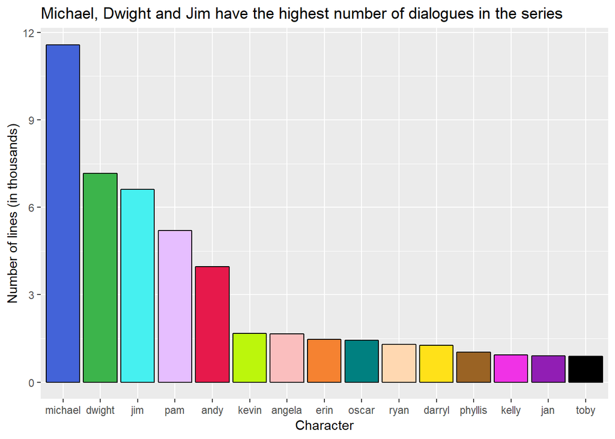

```r
most_lines_graph(dialogues_df)
```

It was obvious we could solve this question, but we faced an issue when we realized there are hundreds of characters with a single line. Since we only care about the main characters, we filtered the top 15 speakers of the entire series, and this was easier to plot.

But does this mean these characters really speak the most? We want to eliminate the possibility that a speaker says several very short lines, which might make them get into the main cast without actually developing a character in the show.

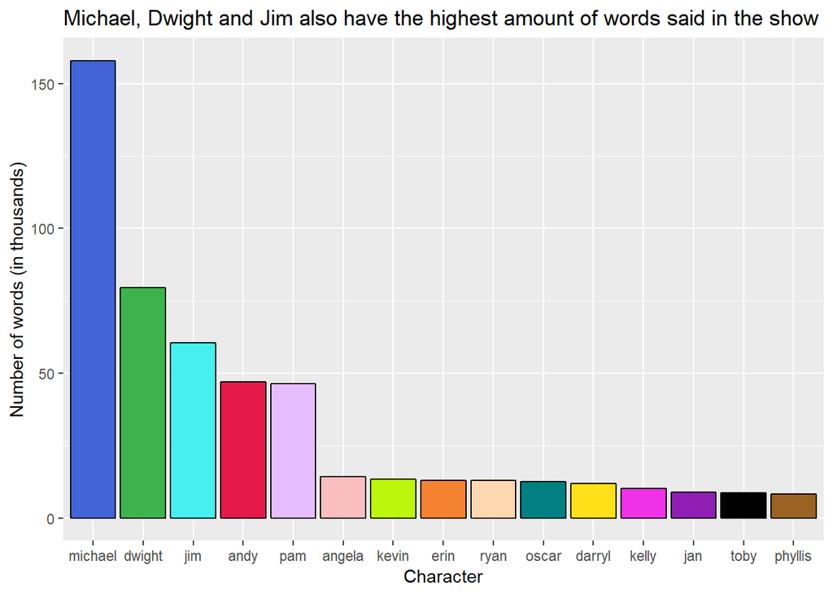

```r
most_words_graph(words_df)
```

The next step to determine if the distribution of screen time is proportional indeed, we would like to find out if there is a relation between the average characters per line of speech for each character, and the maximum length of a line they delivered in the show.

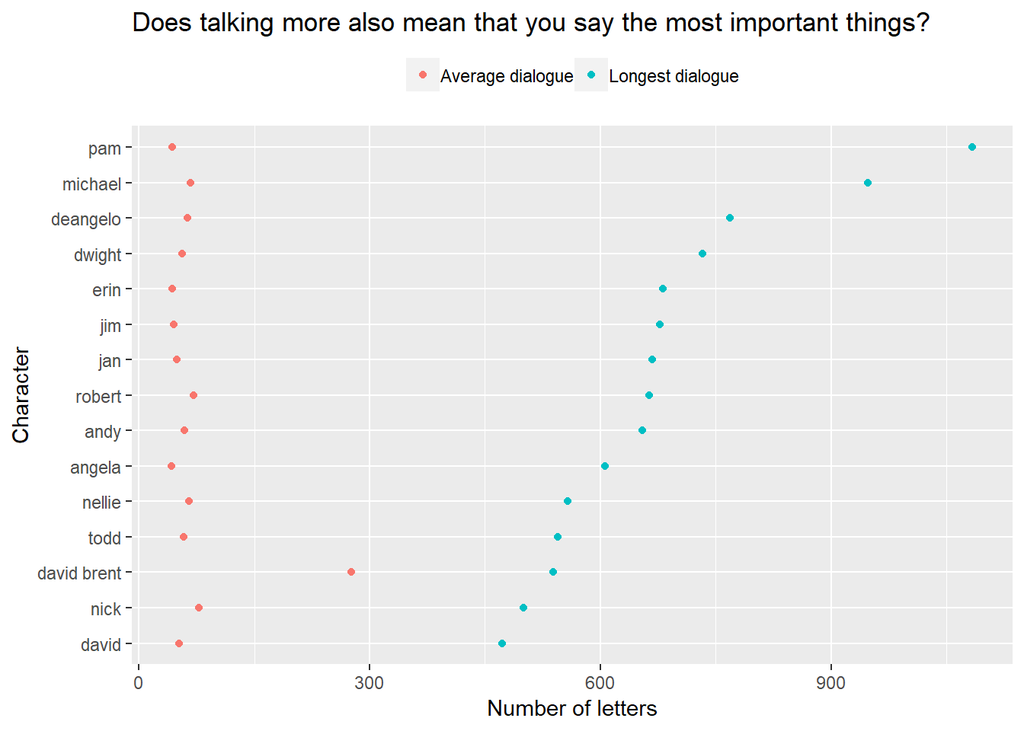

```r
screen_distribution_graph(dialogues_df)
```

From this chart, we can see that the lines of each character in the main cast are of the same length, approximately (although it would be interesting to take a closer look into this matter). We can also determine that the 5 main characters of the show are amongst the 9 characters with the longest line said, which makes sense due to how their characters evolved throughout the show. Particularly, Andy’s longest line in the show is the one that ranks the lowest, with Robert, Jan, Erin and DeAngelo topping him for longest dialogue in the show.

Now that we have our hands in this data, we realized that we can go one level deeper, and replicate at a word level what we just did for dialogues. This might shine some light over a character being portrayed as smarter in the show, as the ability to use more complicated words is linked to the perception of intelligence.

### Longest length of a word is almost 30??

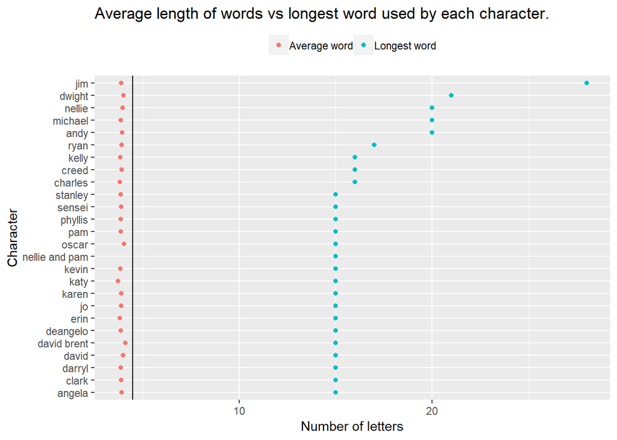

```r
length_words_graph(words_df2)
```

When we first ran this analysis, several characters shared the same number of letters in the longest word. This caught our attention, and we realized we needed to redo the analysis without counting the words joined with an underscore from a previous function.

It is interesting to see that for most of the characters in the main cast, the average number of letters in a word is below that of the English language ([according to Trinity College](http://www.cs.trincoll.edu/~crypto/resources/LetFreq.html)). Given the nature of the show, it is easy to understand that language is kept simple.

This took us to a new question: is it usual for characters to use crutch words? Rather than defining a dictionary of these support words, we decided to leverage on what was available and use the stopwords list again. After all, we assumed this would mean that characters that used words different from those in the dictionary carried more meaning in their dialogues.

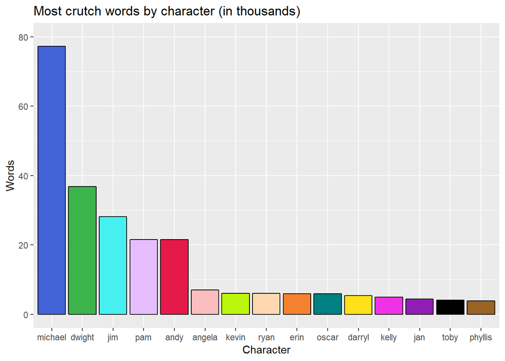

```r
crutches_graph(words_df)
```

Given that our dataset has a field that identifies whether a scene was deleted or not, we decided to look into what characters were cut out the most.

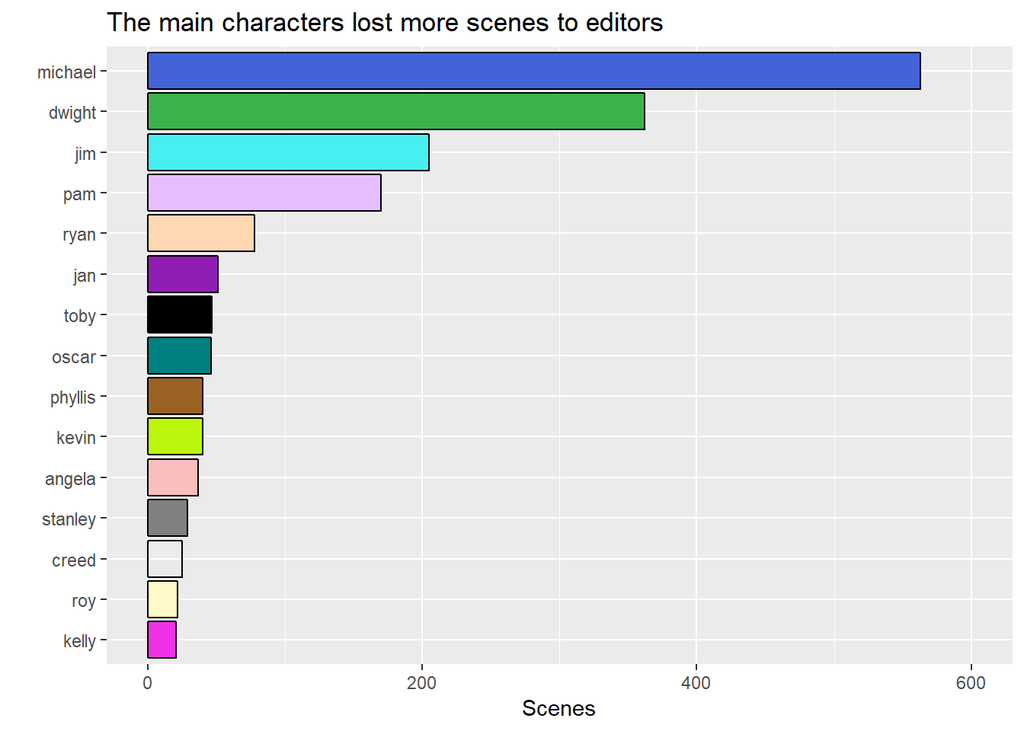

```r
deleted_scenes_graph(theoffice_df)
```

Unsurprisingly, Michael, Dwight, Jim and Pam lost the most scenes in the show. They are some of the main characters, so it made sense that they lost scenes proportionally.

Andy wasn’t in this group, however, which caught our attention. We inspected the data and realized that scenes in the script were only labeled as “deleted” for seasons 1 and 2, before he was added to the cast. Maybe as the show flourished they stopped deleting scenes?

### What can we know about groups of characters and about their interactions?

Now that we know the characters in a closer way, we are moving on to analyzing their interactions. This will help us see if some characters have cloques (as happens normally in a professional setting), or if a character is referenced more than others.

This question seems like a good starting point, so we modelled their interactions by counting within dialogues how many times other characters are mentioned.

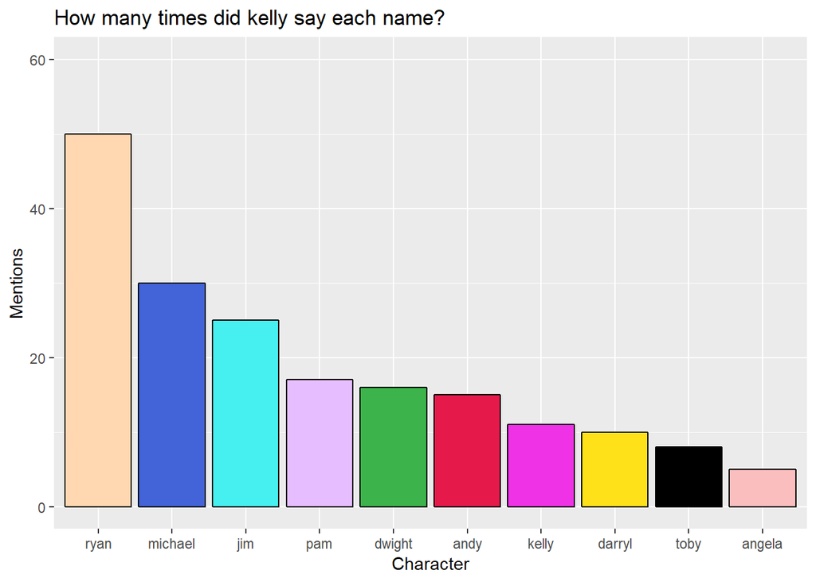

```r
get_graph("kelly")
```

This was a very complicated task, albeit interesting. We now have a way to see whose name is repeated the most by a character. Given the limited space we have in this report, we are including this function in the interactive component of this project, and will leave you to see who is the character most mentioned by Jim (hint: it isn’t Pam!).

This analysis gave us an idea: would it be possible to analyze what characters shared a particular scene? We don’t have complete information (someone might not have a dialogue, yet be on scene), but the scripts are a powerful tool, so we decided to try. We counted, on a scene basis, how many times a character (or a set) appeared. Given the mockumentary style, we didn’t ignore scenes with a single character, as they were talking to the filming crew about their experiences.

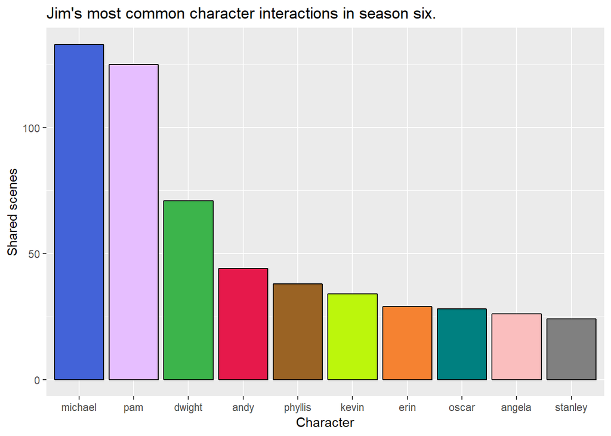

```r
get_most_shared_scenes(words_df,'jim',6)
```

The initial version of this chart was difficult to read, as there were several combinations of characters speaking in the show. This motivated us to dig deeper, as relationships (even fictionals) are built and change over time. In our interactive app, you can choose combinations of characters (only the main cast) and see how they interact season by season. We feel that there is more information in the data than we could write, and invite the reader to see how Jim and Pam’s relationship grows after season one.

### The Office in real life: portrayal of Corporate America and viewership trends through time

By now we have been asking questions about the show, but the one that most readers might have had since the begining is: How many “that’s what she said” gags took place throughout the series?

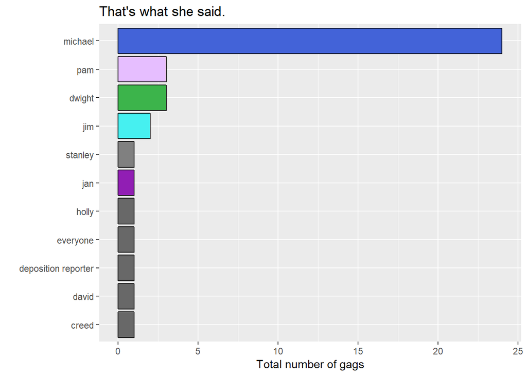

```r
phrase_graph(words_df)
```

Given this was Michael’s joke, it is clear that he was the main contender, with 24 times. It is interesting to think that the scripts don’t carry tone or context, so a character might not have said the phrase as a joke and still ended up in our ranking. This was one of the limitations of our analysis, and it will be hard to fix.

Now that we talk about it, we wantes to know how balanced was the show in terms of gender equality. We cross referenced our original dataframe with a table containing the genders of the 30 main characters of the show, and dived into it hoping to answer our quesiton.

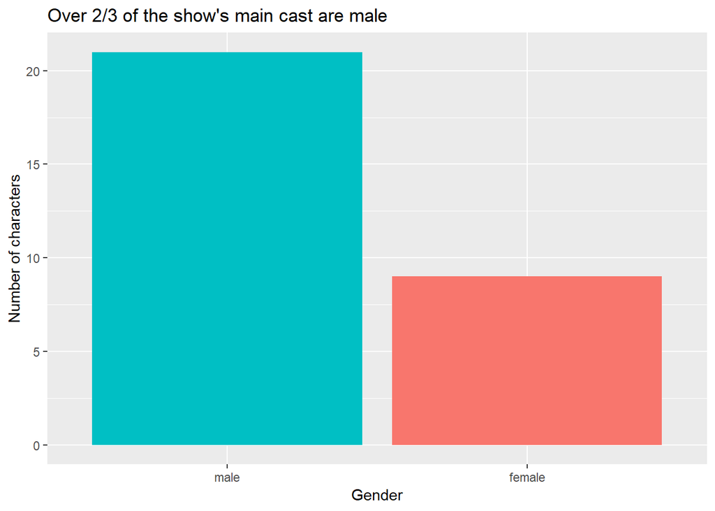

```r
character_gender_graph()
```

First, we found that over 66% of the cast throughout the series were male. Does this represent appropriately the professional setting in the USA? We’re not sure. However, this sets up a baseline for the next question: are dialogues proportional to the number of characters belonging to each gender?

[figure not shown]

```r
dialogues_gender_graph(words_df,dialogues_df)
```

There was a clear evolution in the show, specially in terms of character development and changes in cast. In the competitive environment of sitcoms, shows must continually innovate to keep their rating levels, so we decided to take a look at ratings for the show.

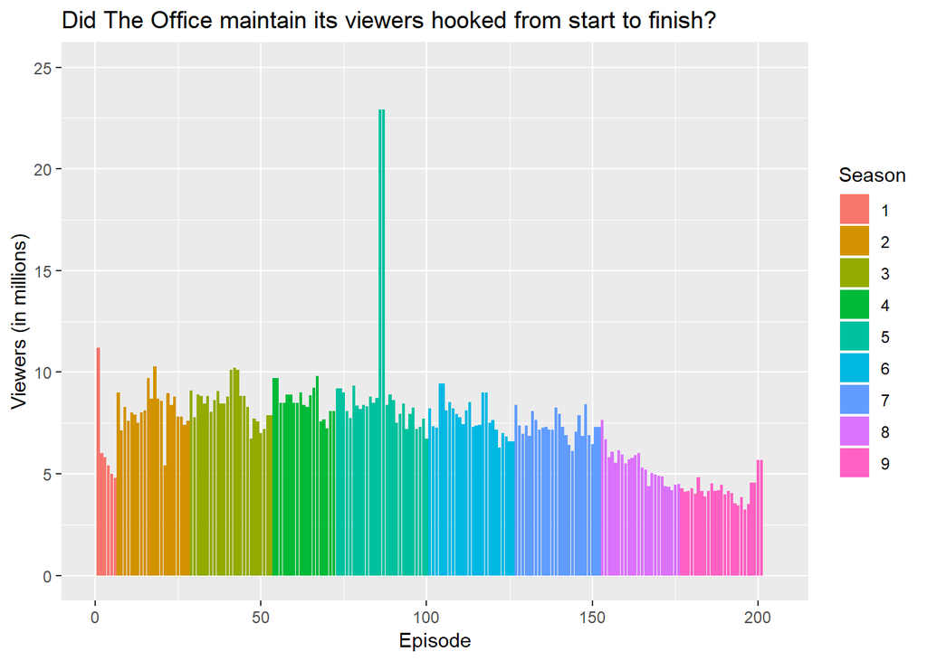

```r
viewers_graph()
```

It is interesting to see spike in viewership for episodes 14 and 15 in season 5, that represented over 2.5 times the usual viewership. We investigated the event and realized the episodes aired right after the SuperBowl, making them outliers in the series.

## Executive Summary.

Upon completing an exploratory analysis through the dialogues of the sitcom “The Office”, we want to share some of the most relevant findings we made. Guided by our initial framework, we focused on exploring the data behind individual characters, how they interacted, and other factors that related the show to its social setting.

Our dive into individual characters helped us see how the 5 top characters dominate the dialogues in the show, as each one of them has between 4 and 12 thousand lines of speech. This is relevant, as some of the main characters didn’t participate in all 9 seasons.

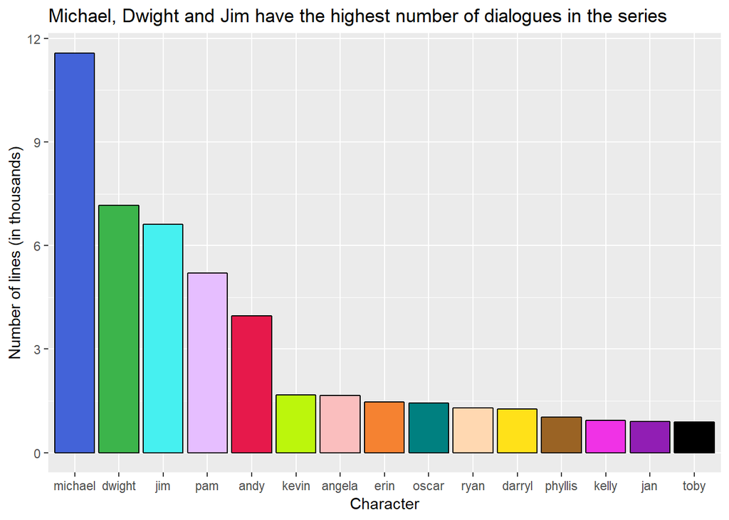

```r
most_lines_graph(dialogues_df)
```

It is also interesting to see how dialogues are driven by stop words, as these words dominate their speech. This is quite inefficient in communication, but we can understand that this might be a consequence of the high number of scenes where characters were facing the documentary camera, without interacting with anyone else.

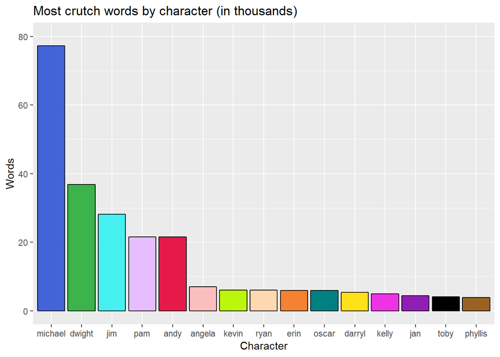

```r
crutches_graph(words_df)
```

We had many laughs over the show, but how many more could we have had? Jim, Dwight and Michael lost over 1,000 scenes in total, due to editing. It’s shocking that this happened only during the first 2 seasons! Maybe they were not funny or appropriate, but we can only imagine what they said.

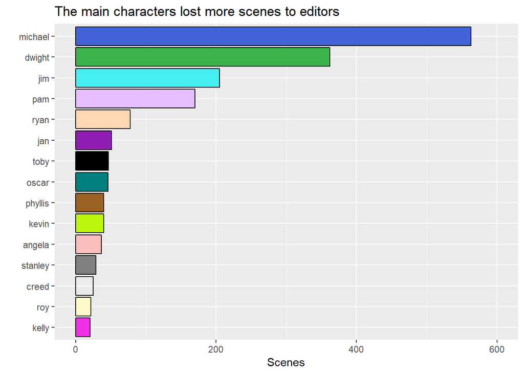

```r
deleted_scenes_graph(theoffice_df)
```

Regarding our review on the interactions amongst characters, we were able to identify some unexpected relationships, like Jim saying Dwight’s name more than Pam’s.

We could further explain our findings, but we’d rather invite you to make your own. [This link](https://opardo.shinyapps.io/shiny/) contains a Shiny App where you can explore more information about the show’s dialogues through all 9 seasons.

For the final area under study, we wanted to understand the setting in which the show developed. We believe that the two questions that held the most important findings dealt with gender equality and with ratings.

[figure not shown]

```r
dialogues_gender_graph(words_df,dialogues_df)
```

Finally, our analysis took us to investigate if there was a decline in ratings causing a cancellation of the series. We found that ratings were dropping throughout the seasons, but the decline rate grew for seasons 8 and 9. Was the audience tired of this show? It’s not that likely. Was it due to Michael’s character leaving the show? Probably.

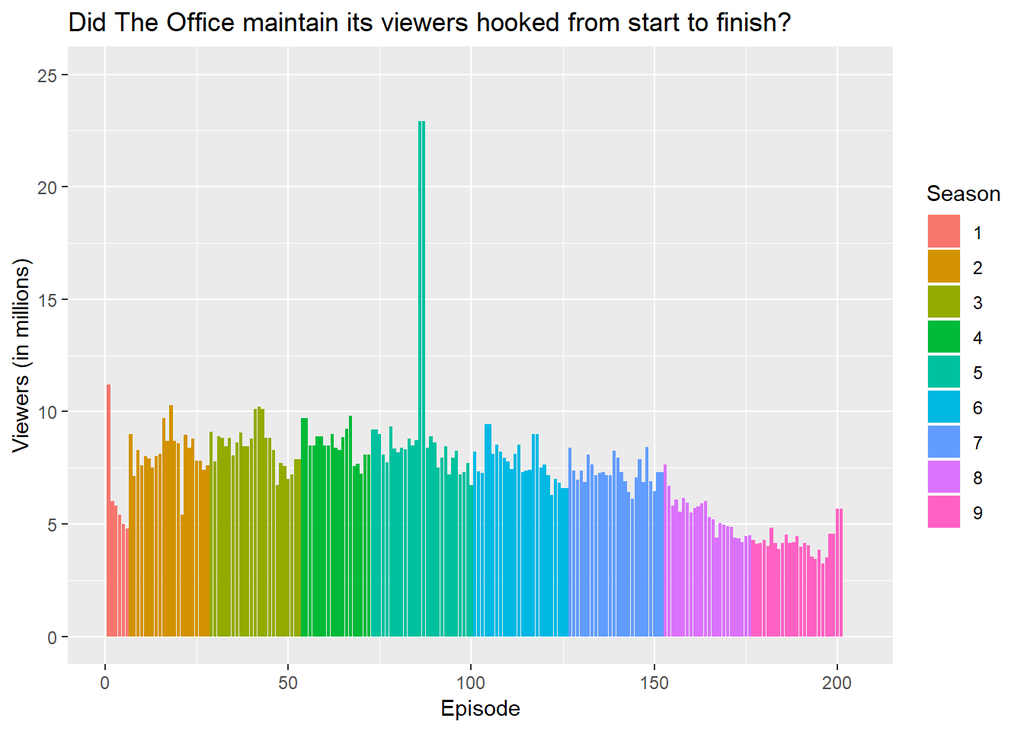

```r
viewers_graph()
```

## Interactive component.

As we previously mentioned, it was very interesting to see how the interaction of characters evolved in the show, so we decided to move those elements to a [Shiny App](https://opardo.shinyapps.io/shiny/). Although we reached some conclusions through this analysis - confirming what our experience as viewers had told us - we believe the real finding here is that summarizing data in a graphical way allows the user to process information faster and easier.

As a starting point, may we suggest you see in which season do Andy’s interactions with the cast start, or how do interactions with Michael change after season 7?

By creating an App that lets users choose their favorite characters and see who they interacted with through each season, we avoided cluttering this document with text, and help our readers reach their own conclusions. We expect that the interactive component of this project will assist our audience in improving their knowledge in popular culture and remembering the fun they had while watching the show.

## Conclusion.

We believe the main challenge in this project was remaining succinct in a matter we are so passionate about. Upon each answer to a question we might have asked, we could find several more, sometimes more interesting, that we couldn’t include in a report. We appreciated the existence of a framework that could guide how to ask each question, how to assign it to a subject, and how to develop it with the objective of communicating our findings to an audience.

Although the dataset was priceless, in that it helped us learn more about the show, we found it was a very limited tool from a Data Scientist perspective. It only helped us determine what was being said during a scene, but not much else. As a follow-up step, we would look into the actions written in the scripts (Wrileys), to understand a bit more of what happened in a given scene.

A further limitation was our need to establish constructs for the questions we asked to the data. For instance, we had to find an indicator that could help us understand if an average word was long or not; however, for complex questions, building a baseline implied specilating, and we hoped to remain neutral. We lacked the tools, for instance, to conclude whether Michael was indeed smarter than Oscar. This was a trivial one, but it shows the difficulties faced when working with a natural language database.

A step we would like to continue with in this project is to use tf-idf to determine the most important word for a given character or episode, and ask our audience if they can help us identify them. This feature was deemed as a nice-to-have in the assignment, as it was not related to exploratory analysis, and thus wasn’t a priority that could be met with the time we had.

## Bibliography.

1. The-office-lines. (n.d.). Retrieved November 10, 2018, from https://docs.google.com/spreadsheets/d/18wS5AAwOh8QO95RwHLS95POmSNKA2jjzdt0phrxeAE0/edit#gid=747974
2. List of The Office (U.S. TV series) episodes. (2018, November 07). Retrieved December 5, 2018, from https://en.wikipedia.org/wiki/List_of_The_Office_(U.S._TV_series)_episodes
3. Percentages of Letter Frequencies per 1000 Words. (n.d.). Retrieved December 8, 2018, from http://www.cs.trincoll.edu/~crypto/resources/LetFreq.html
4. OfficeQuotes.net - The Comprehensive Source for The Office Quotes! (n.d.). Retrieved November 10, 2018, from http://officequotes.net/